# Capstone EDA

Jared Allen

07/11/2019

## Introduction

The first step in building a predictive model for text is understanding the distribution and relationship between the words, tokens, and phrases in the text. The goal of this task is to understand the basic relationships you observe in the data and prepare to build your first linguistic models.

Tasks to accomplish

Exploratory analysis - perform a thorough exploratory analysis of the data, understanding the distribution of words and relationship between the words in the corpora.

Understand frequencies of words and word pairs - build figures and tables to understand variation in the frequencies of words and word pairs in the data.

## Data Import

Data import has been accomplished through the use of the readLines function in R, storing the data in tibble format to adhere to tidy data principles. The three datafiles to be explored in this analysis consist of data from twitter, data from blogposts, and data from news sites.

```r
con<- file("Data/final/en_US/en_US.twitter.txt","r")
en_us_twitter <- readLines(con)
en_us_twitter <- tibble(en_us_twitter)
close(con)

con<- file("Data/final/en_US/en_US.blogs.txt","r")
en_us_blogs <- readLines(con)
en_us_blogs <- tibble(en_us_blogs)
close(con)

con<- file("Data/final/en_US/en_US.news.txt","r")
en_us_news <- readLines(con)
en_us_news <- tibble(en_us_news)
close(con)
```

| source | lines | tokens | tokens_per_line |
| --- | --- | --- | --- |
| blogs | 899288 | 38154238 | 42.42716 |
| news | 77259 | 2693898 | 34.86840 |
| twitter | 2360148 | 30218125 | 12.80349 |

An initial look at the data shows that each of the data sets has a large quantity of data, with twitter messages tending to be very short, with an average of 12.8 words per entry, while news and blog articles have 34.8 and 42.4 words per entry respectively.

The large amount of data (899288 rows in the blog data, 77259 in the news data, and 2360148 rows in the twitter data) makes exploratory analysis of the entire dataset resource intensive. For this reason, a randomly selected subset consisting of 5% of each of the datasets will be used to characterise the data prior to analysis.

Preliminary examination of the blog dataset showed that at some point, apostrophes had been converted into the symbol “â” followed by a space in the dataset. These will be removed via a str_remove prior to further analysis. tidytext techniques have then been used to unnest the data into unigram, bigram, and trigram datets. The most prevalent words for each n-gram are shown here:

| unigram | n |
| --- | --- |
| the | 147316 |
| to | 96677 |
| and | 79785 |
| a | 79143 |
| i | 78389 |
| of | 64555 |
| in | 51481 |
| you | 43319 |
| is | 40868 |
| for | 39018 |

| bigram | n |
| --- | --- |
| of the | 13015 |
| in the | 12253 |
| to the | 6814 |
| for the | 6786 |
| on the | 6480 |
| to be | 6082 |
| at the | 4428 |
| i have | 4031 |
| and the | 3921 |
| i was | 3858 |

| trigram | n |
| --- | --- |
| NA | 5234 |
| thanks for the | 1149 |
| one of the | 1115 |
| a lot of | 905 |
| to be a | 712 |
| going to be | 653 |
| i want to | 643 |
| i have a | 556 |
| i don t | 549 |
| it was a | 523 |

As the project aims to predict the next word based on prior entries, stop words will need to be retained in the final model in order to maintain grammatical order. However their high weighting necessitates their removal from this exploratory analysis, along with punctuation, numbers and symbols, which were removed using the unnest_tokens function.

This then allows counts of the clean n grams with stop words removed:

| unigram | n |
| --- | --- |
| time | 8590 |
| love | 7565 |
| day | 7310 |
| people | 5856 |
| rt | 4460 |
| life | 3855 |
| lol | 3699 |
| night | 3243 |
| happy | 3133 |
| week | 2907 |

| bigram | n |
| --- | --- |
| happy birthday | 422 |
| social media | 256 |
| mother’s day | 190 |
| ice cream | 178 |
| stay tuned | 159 |
| san diego | 143 |
| los angeles | 131 |
| mothers day | 126 |
| weeks ago | 117 |
| happy hour | 116 |

| trigram | n |
| --- | --- |
| happy mother’s day | 86 |
| happy mothers day | 82 |
| cinco de mayo | 64 |
| sex sex sex | 29 |
| blah blah blah | 27 |
| hunter matt hunter | 27 |
| matt hunter matt | 27 |
| st patrick’s day | 27 |
| love love love | 26 |
| gas gas gas | 20 |
| happy valentine’s day | 20 |
| martin luther king | 20 |

To examine differences between the data sources, the frequency of n grams by source is calculated:

Examination of the top n-grams for each data source reveals some interesting differences between the texts. While unigram data shows similar single word usage between the three sources, with “time”, “day”, and “people” showing up as having high relative frequencies in all three of the sets.

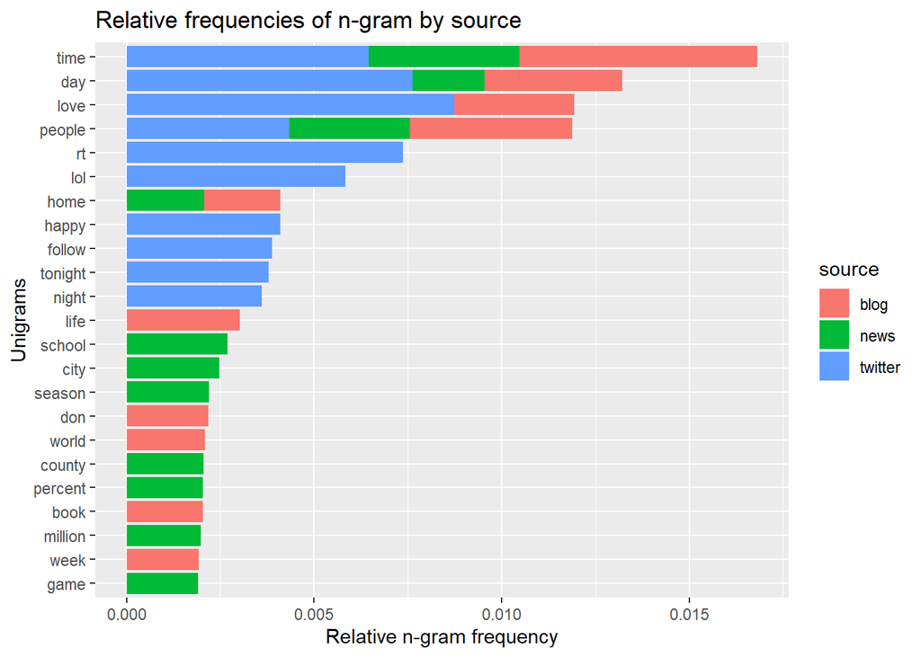

Examination of bigram and trigram data starts to give information about how the different sources are used. Exploration of the bigrams shows “happy birthday”, “mother’s day”, “happy hour”, and “merry christmas” having a high weighting in the twitter dataset, being evidence of this channel being used heavily for short celebratory messages or advertising, news data shows a high prevalence of place names in the bigram data, and blogs show the bigrams “social media”, “weeks ago”, “months ago”, and “real life”, suggesting these are predominantly a media which relays experiential data.

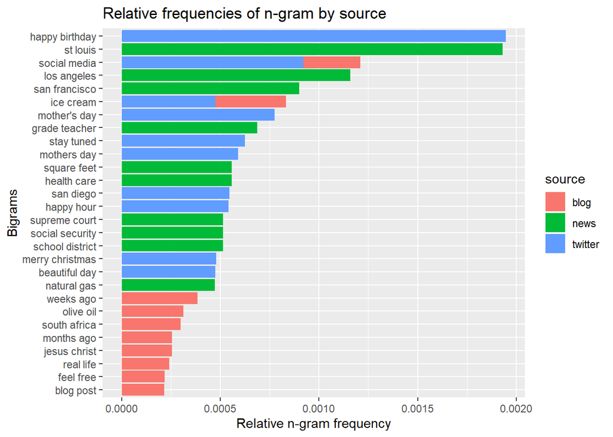

Finally the trigram data again shows a high weighting for holidays in the twitter data, with “happy mothers day”, “cinco de mayo”, and “st patrick’s day” having high relative prevalence, news data shows a proclivity towards real names in the trigrams, such as “st louis county”, and “gov chris christie”. At the trigram level, the blog data is heavily skewed towards advertisements, with amazon website lists showing a high relative frequency. At the trigram level the twitter data also reveals a trend in tweets for nonsense tweets with words or phrases being repeated a high number of times, such as “sex sex sex” and “matt hunter matt”, a predictive model will need to filter out such data to prevent it from skewing predictions.

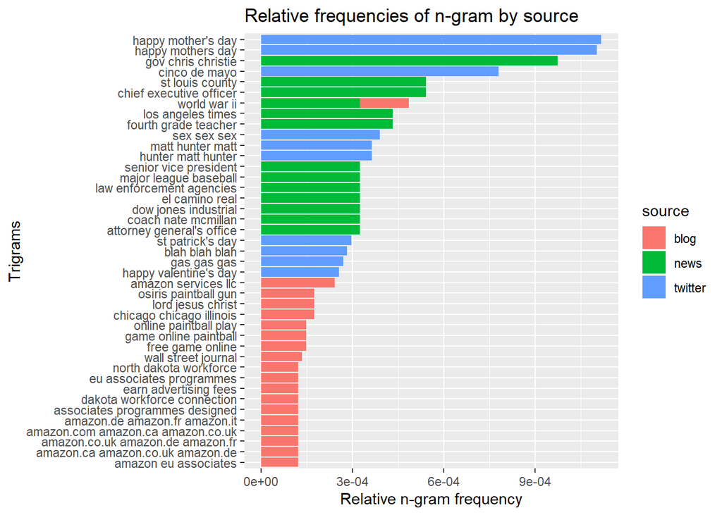